# Measures of Location: Third Moment

[John S Butler (TU Dublin)](https://johnsbutler.netlify.com)

# Third Moment: Skeness

## Skewness

### Definition:

Skewness is a measure of symmetry (or not symmetry) of a distribution. Pearson’s Coefficient of Skewness number 1 uses the mode to calculate skewness, given by the formula is:
$$sk_1=\frac{\bar{x}-Mode(x)}{\sigma}$$
Pearson’s Coefficient of Skewness number 2 uses the median to calculate skewness, given by the formula is:
$$sk_2=3\frac{\bar{x}-Median(x)}{\sigma}$$
,

where $\bar{x}$ is the average of the elements, $\sigma$ is the standard deviation, $Mode(x)$ is the mode of the elements and $Median(x)$ is the median of the elements.

### Symmetric Example

The figure below shows a symmetric histogram of 2000 concert attendees ages observations at a concert:

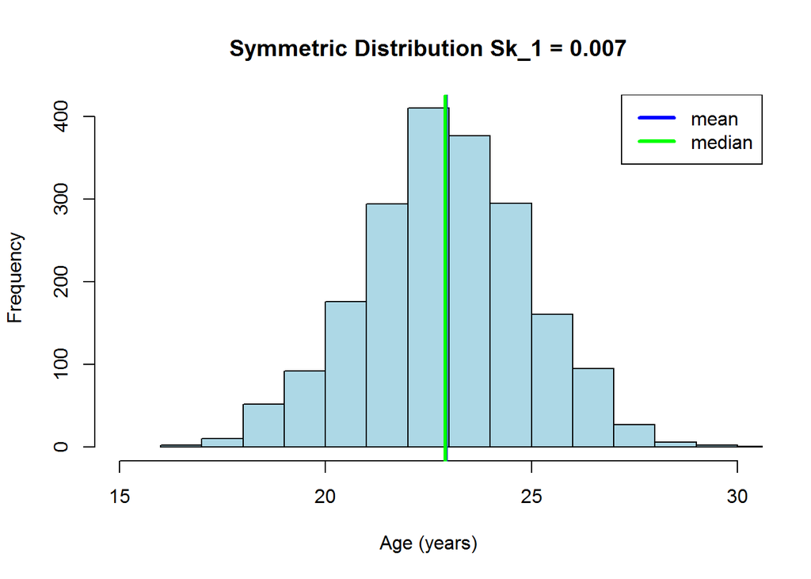

```r
Age<-rnorm(2000,23,2)
sk_title = paste0("Symmetric Distribution Sk_1 = ",round((mean(Age)-median(Age))/sd(Age), digits = 3))
hist(Age,col="lightblue",xlab="Age (years)",xlim=c(15,30),main=sk_title) # Histogram of the 7 numbers
abline(v=mean(Age),col="blue",lwd=3)# line indicating the mean
abline(v=median(Age),col="green",lwd=3)# line indicating the mean
legend("topright",c("mean","median"),lwd=c(3,3),lty=c(1,1),col=c("blue","green"))
```

### Positive Skewness Example

The figure below shows a positive skewness histogram of 2000 attendees age observations at a concert:

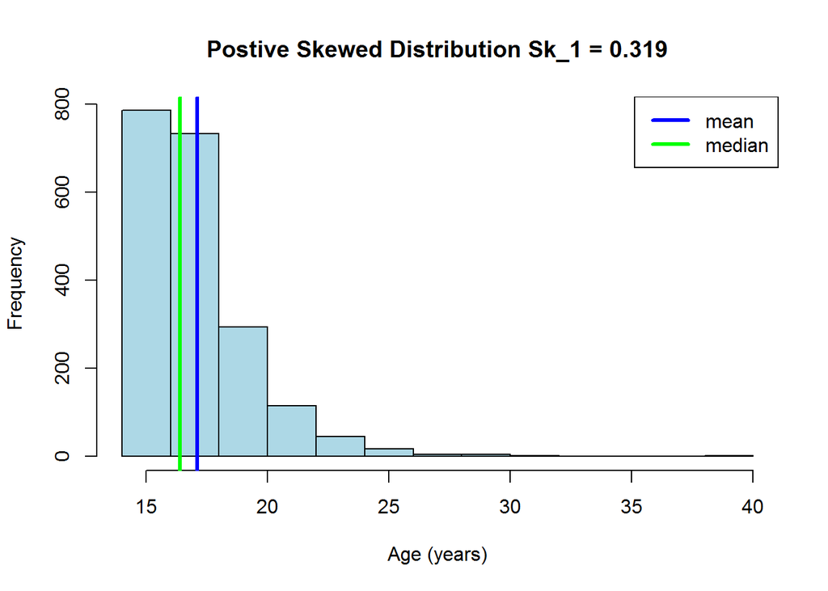

```r
Age<-rchisq(2000,2)+15
sk_title = paste0("Postive Skewed Distribution Sk_1 = ", round((mean(Age)-median(Age))/sd(Age), digits = 3))
hist(Age,col="lightblue",xlab="Age (years)",main=sk_title) # Histogram of the 7 numbers
abline(v=mean(Age),col="blue",lwd=3)# line indicating the mean
abline(v=median(Age),col="green",lwd=3)# line indicating the mean
legend("topright",c("mean","median"),lwd=c(3,3),lty=c(1,1),col=c("blue","green"))
```

### Negative Skewness Example

The figure below shows a negative skewness histogram of 2000 attendees age observations at a Andre Rieu concert:

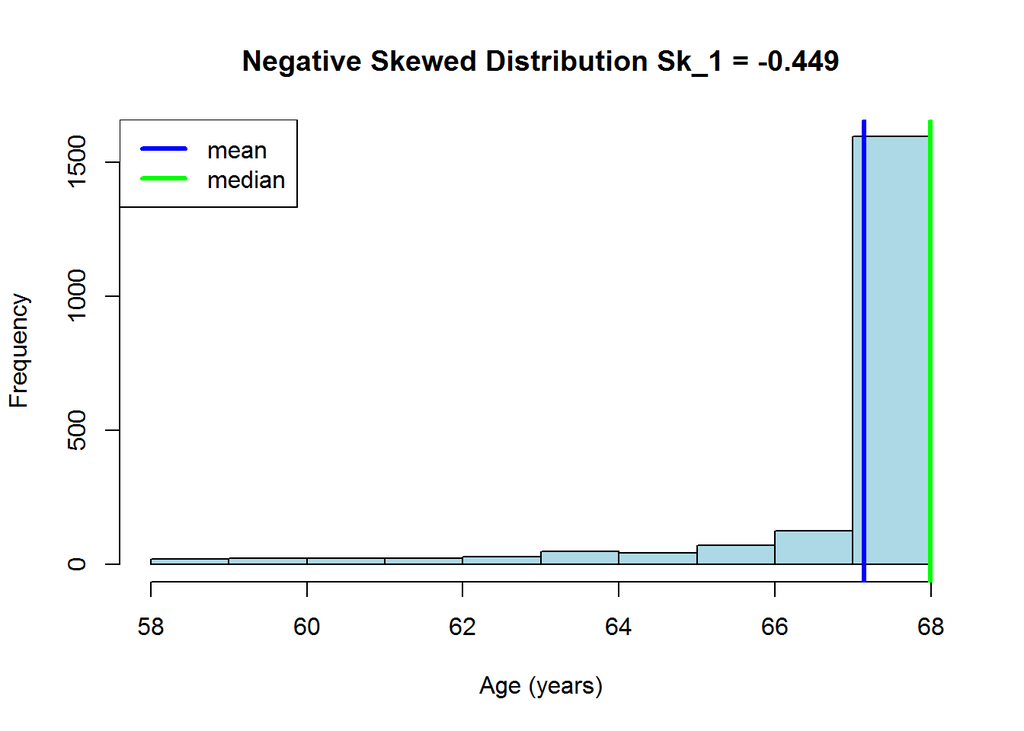

```r
Age<-rbeta(2000,1,0.1)*10+58
sk_title = paste0("Negative Skewed Distribution Sk_1 = ", round((mean(Age)-median(Age))/sd(Age), digits = 3))
hist(Age,col="lightblue",xlab="Age (years)",main=sk_title) # Histogram of the 7 numbers
abline(v=mean(Age),col="blue",lwd=3)# line indicating the mean
abline(v=median(Age),col="green",lwd=3)# line indicating the mean
legend("topleft",c("mean","median"),lwd=c(3,3),lty=c(1,1),col=c("blue","green"))
```

### Bi-modal

The figure below shows a histogram of 3000 attendees age observations at a Wiggles concert:

[figure not shown]

```r
Age<-c(rnorm(2000,10,1.5),rnorm(1000,40,6))
sk_title = paste0("Symmetric Distribution Sk_1 = ", round((mean(Age)-median(Age))/sd(Age), digits = 3))
hist(Age,col="lightblue",xlab="Age (years)",main=sk_title,breaks=300) # Histogram of the 7 numbers
abline(v=mean(Age),col="blue",lwd=3)# line indicating the mean
abline(v=median(Age),col="green",lwd=3)# line indicating the mean
legend("topleft",c("mean","median"),lwd=c(3,3),lty=c(1,1),col=c("blue","green"))
```